# Central and Eastern Europe - Oxford Handbooks

Central and Eastern Europe

## Maciej Karpiński Maciej KarpińskiModern Languages and Literatures, Adam Mickiewicz University , Bistra Andreeva Bistra AndreevaLanguage Science and Technology, Saarland University , Eva Liina Asu Eva Liina AsuEstonian and General Linguistics, University of Tartu , Anna Daugavet Anna DaugavetLinguistics, Saint-Petersburg State University , Štefan Beňuš Štefan BeňušEnglish and American Studies, Constantine the Philosopher University , and Katalin Mády Katalin MádyLinguistics, Hungarian Academy of Sciences

[The Oxford Handbook of Language Prosody](https://www.oxfordhandbooks.com/view/10.1093/oxfordhb/9780198832232.001.0001/oxfordhb-9780198832232)

## Edited by Carlos Gussenhoven and Aoju Chen

**Print Publication Date:**

Dec 2020

**Subject:**

Linguistics, Phonetics and Phonology

**Online Publication Date:**

Feb 2021

**DOI:**

10.1093/oxfordhb/9780198832232.013.14

## In This Article

# Central and Eastern Europe

## Abstract and Keywords

The languages of Central and Eastern Europe addressed in this chapter form a typologically divergent collection that includes Slavic (Belarusian, Bulgarian, Czech, Macedonian, Polish, Russian, pluricentric Bosnian-Croatian-Montenegrin-Serbian, Slovak, Slovenian, Ukrainian), Baltic (Latvian, Lithuanian), Finno-Ugric (Hungarian, Finnish, Estonian), and Romance (Romanian). Their prosodic features and structures have been explored to various depths, from different theoretical perspectives, sometimes on the basis of relatively sparse material. Still, enough is known to see that their typological divergence as well as other factors contribute to vivid differences in their prosodic systems. While belonging to intonational languages, they differ in pitch patterns and their usage, duration, and rhythm (some involve phonological duration), as well as prominence mechanisms, accentuation, and word stress (fixed or mobile). Several languages in the area have what is referred to by different traditions as pitch accents, tones or syllable accents, or intonations.

Keywords: Slavic, Baltic, Finno-Ugric, Romance, intonation, [pitch patterns](https://www.oxfordhandbooks.com/search?f_0=keyword&q_0=pitch%20patterns), [phonological duration](https://www.oxfordhandbooks.com/search?f_0=keyword&q_0=phonological%20duration), [prominence mechanisms](https://www.oxfordhandbooks.com/search?f_0=keyword&q_0=prominence%20mechanisms), accentuation, [word stress](https://www.oxfordhandbooks.com/search?f_0=keyword&q_0=word%20stress), [pitch accent](https://www.oxfordhandbooks.com/search?f_0=keyword&q_0=pitch%20accent)

# 15.1 Introduction

The languages of Central and Eastern Europe form a typologically divergent collection that includes Baltic (Latvian, Lithuanian), Finno-Ugric (Estonian, Finnish, Hungarian), Slavic (Belarusian, Bulgarian, Czech, Macedonian, Polish, Russian, pluricentric Bosnian-Croatian-Montenegrin-Serbian (BCMS), Slovak, Slovenian, Ukrainian), and Romance (Romanian). Most of them have well-established positions as official state languages, but there are also a good many minority and regional languages varying in their history, status, and number of speakers (e.g. Sorbian, Latgalian, Kashubian, a number of Uralic languages, and groups of Romani dialects).

Slavic and Baltic languages are assumed to have emerged from a hypothetical common ancestor—Proto-Balto-Slavic (also referred to as very late Proto-Indo-European; Comrie and Corbett [1993](https://www.oxfordhandbooks.com/view/10.1093/oxfordhb/9780198832232.001.0001/oxfordhb-9780198832232-bibliography-1#oxfordhb-9780198832232-bibliography-1-bibItem-814): 62)—and to have split some 2,000 years ago (Mallory and Adams [2006](https://www.oxfordhandbooks.com/view/10.1093/oxfordhb/9780198832232.001.0001/oxfordhb-9780198832232-bibliography-1#oxfordhb-9780198832232-bibliography-1-bibItem-2815): 103–104). Slavic broke up into East, West, and South Slavic (Mallory and Adams [2006](https://www.oxfordhandbooks.com/view/10.1093/oxfordhb/9780198832232.001.0001/oxfordhb-9780198832232-bibliography-1#oxfordhb-9780198832232-bibliography-1-bibItem-2815): 14, 26; Sussex and Cubberley [2006](https://www.oxfordhandbooks.com/view/10.1093/oxfordhb/9780198832232.001.0001/oxfordhb-9780198832232-bibliography-1#oxfordhb-9780198832232-bibliography-1-bibItem-4077); Clackson [2007](https://www.oxfordhandbooks.com/view/10.1093/oxfordhb/9780198832232.001.0001/oxfordhb-9780198832232-bibliography-1#oxfordhb-9780198832232-bibliography-1-bibItem-772): 8, 19). Romanian (Eastern Romance) arose from the Romanization of Dacia in the first centuries ad and the later invasion of Goths (Du Nay [1996](https://www.oxfordhandbooks.com/view/10.1093/oxfordhb/9780198832232.001.0001/oxfordhb-9780198832232-bibliography-1#oxfordhb-9780198832232-bibliography-1-bibItem-1155)). Hungarian is considered to have emerged from the Ugric branch of Proto-Uralic, while Estonian and Finnish belong to the Finnic branch (Abondolo [1998](https://www.oxfordhandbooks.com/view/10.1093/oxfordhb/9780198832232.001.0001/oxfordhb-9780198832232-bibliography-1#oxfordhb-9780198832232-bibliography-1-bibItem-12)).

Beyond genetic relations, it was migration, language policy, and language contacts that shaped the present linguistic picture of Central and Eastern Europe, including many prosodic aspects. This chapter discusses the word prosody (§15.2) and sentence prosody (§15.3) of the major languages of the region.

# (p. 226) 15.2 Word prosody

## 15.2.1 Quantity

Quantity distinctions play an important role in the word prosody in the region and may involve consonants in addition to vowels. In the majority of cases, vowel quantity distinctions are accompanied by a difference in vowel quality (e.g. Kovács [2002](https://www.oxfordhandbooks.com/view/10.1093/oxfordhb/9780198832232.001.0001/oxfordhb-9780198832232-bibliography-1#oxfordhb-9780198832232-bibliography-1-bibItem-2460); Podlipský et al. [2009](https://www.oxfordhandbooks.com/view/10.1093/oxfordhb/9780198832232.001.0001/oxfordhb-9780198832232-bibliography-1#oxfordhb-9780198832232-bibliography-1-bibItem-3434); Skarnitzl and Volín [2012](https://www.oxfordhandbooks.com/view/10.1093/oxfordhb/9780198832232.001.0001/oxfordhb-9780198832232-bibliography-1#oxfordhb-9780198832232-bibliography-1-bibItem-3953); Grigorjevs and Jaroslavienė [2015](https://www.oxfordhandbooks.com/view/10.1093/oxfordhb/9780198832232.001.0001/oxfordhb-9780198832232-bibliography-1#oxfordhb-9780198832232-bibliography-1-bibItem-1690)).

### 15.2.1.1 Baltic

Latvian and Lithuanian have a quantity contrast in vowels, and Latvian has additionally developed contrastive quantity in consonants. Some dialects have lost quantity in unstressed syllables. The durational proportion between short and long vowels, pronounced in isolation, has been shown to be 1:2.1 for both Latvian (Grigorjevs [2008](https://www.oxfordhandbooks.com/view/10.1093/oxfordhb/9780198832232.001.0001/oxfordhb-9780198832232-bibliography-1#oxfordhb-9780198832232-bibliography-1-bibItem-1689)) and Lithuanian (Jaroslavienė [2015](https://www.oxfordhandbooks.com/view/10.1093/oxfordhb/9780198832232.001.0001/oxfordhb-9780198832232-bibliography-1#oxfordhb-9780198832232-bibliography-1-bibItem-2169)). In Lithuanian, short open vowels are lengthened under stress in non-final syllables in the word, except in certain grammatical forms; see (1) below (Girdenis [1997](https://www.oxfordhandbooks.com/view/10.1093/oxfordhb/9780198832232.001.0001/oxfordhb-9780198832232-bibliography-1#oxfordhb-9780198832232-bibliography-1-bibItem-1543)). In Latvian, voiceless intervocalic obstruents are lengthened if preceded by a short stressed vowel, which has been attributed to Finnic influence (Daugavet [2013](https://www.oxfordhandbooks.com/view/10.1093/oxfordhb/9780198832232.001.0001/oxfordhb-9780198832232-bibliography-1#oxfordhb-9780198832232-bibliography-1-bibItem-949)).

### 15.2.1.2 Finno-Ugric

Estonian has developed a three-way quantity system with short (Q1), long (Q2), and overlong (Q3) degrees, where duration closely interacts with stress and tone (Lehiste [1997](https://www.oxfordhandbooks.com/view/10.1093/oxfordhb/9780198832232.001.0001/oxfordhb-9780198832232-bibliography-1#oxfordhb-9780198832232-bibliography-1-bibItem-2635)). A decisive factor in determining the degree of quantity is the duration ratio of the first (stressed) syllable and the second (unstressed) syllable in a disyllabic foot (Lehiste [1960a](https://www.oxfordhandbooks.com/view/10.1093/oxfordhb/9780198832232.001.0001/oxfordhb-9780198832232-bibliography-1#oxfordhb-9780198832232-bibliography-1-bibItem-2627)), while pitch remains a vital cue for distinguishing the long and overlong quantity degrees (e.g. Lehiste [1975](https://www.oxfordhandbooks.com/view/10.1093/oxfordhb/9780198832232.001.0001/oxfordhb-9780198832232-bibliography-1#oxfordhb-9780198832232-bibliography-1-bibItem-2631); Danforth and Lehiste [1977](https://www.oxfordhandbooks.com/view/10.1093/oxfordhb/9780198832232.001.0001/oxfordhb-9780198832232-bibliography-1#oxfordhb-9780198832232-bibliography-1-bibItem-935); Eek [1980a](https://www.oxfordhandbooks.com/view/10.1093/oxfordhb/9780198832232.001.0001/oxfordhb-9780198832232-bibliography-1#oxfordhb-9780198832232-bibliography-1-bibItem-1200), [1980b](https://www.oxfordhandbooks.com/view/10.1093/oxfordhb/9780198832232.001.0001/oxfordhb-9780198832232-bibliography-1#oxfordhb-9780198832232-bibliography-1-bibItem-1201); Lippus [2011](https://www.oxfordhandbooks.com/view/10.1093/oxfordhb/9780198832232.001.0001/oxfordhb-9780198832232-bibliography-1#oxfordhb-9780198832232-bibliography-1-bibItem-2719)). In disyllabic Q1 and Q2 feet, the f0 steps down between the two syllables, while in Q3 feet there is an f0 fall early in the first syllable.

In Finnish, both consonant and vowel durations are contrastive, independent of each other and of word stress. That is, short and long vowels may occur before and after both short and long consonants in both stressed and unstressed syllables (Suomi et al. [2008](https://www.oxfordhandbooks.com/view/10.1093/oxfordhb/9780198832232.001.0001/oxfordhb-9780198832232-bibliography-1#oxfordhb-9780198832232-bibliography-1-bibItem-4073): 39). As in Estonian, in Finnish the f0 contour may act as a secondary cue for distinguishing phonological quantities (Lehtonen [1970](https://www.oxfordhandbooks.com/view/10.1093/oxfordhb/9780198832232.001.0001/oxfordhb-9780198832232-bibliography-1#oxfordhb-9780198832232-bibliography-1-bibItem-2640); O’Dell [2003](https://www.oxfordhandbooks.com/view/10.1093/oxfordhb/9780198832232.001.0001/oxfordhb-9780198832232-bibliography-1#oxfordhb-9780198832232-bibliography-1-bibItem-3234); Järvikivi et al. [2007](https://www.oxfordhandbooks.com/view/10.1093/oxfordhb/9780198832232.001.0001/oxfordhb-9780198832232-bibliography-1#oxfordhb-9780198832232-bibliography-1-bibItem-2171); Vainio et al. [2010](https://www.oxfordhandbooks.com/view/10.1093/oxfordhb/9780198832232.001.0001/oxfordhb-9780198832232-bibliography-1#oxfordhb-9780198832232-bibliography-1-bibItem-4257)).

Additionally, Hungarian differentiates between short and long vowels and consonants, although the quantity contrast for consonants is less crucial, as various phonotactic constraints make consonant length predictable (Siptár and Törkenczy [2007](https://www.oxfordhandbooks.com/view/10.1093/oxfordhb/9780198832232.001.0001/oxfordhb-9780198832232-bibliography-1#oxfordhb-9780198832232-bibliography-1-bibItem-3948)).

### 15.2.1.3 Slavic

The historically widespread presence of vowel quantity in the area is now absent from Bulgarian, Macedonian, Polish, Ukrainian, Belarusian, and Russian, and it never existed in the only Romance language in the region, Romanian. It is preserved in Czech, Slovak, Slovenian, and pluricentric BCMS. It is found in stressed and unstressed syllables in Czech, Slovak, and BCMS, where long vowels are, however, excluded from a pre-stressed position. In Slovenian, phonological quantity is present only in final stressed syllables, stressed vowels being otherwise long and unstressed short.

(p. 227) Syllabic /l/ and /r/ occur in Czech and Slovak, and syllabic /r/ in South Slavic. Syllabic liquids participate in the quantity contrast in Slovak and BCMS, but in Slovenian the only syllabic liquid /r/ is always long.

Duration ratios between short and long nuclei, relevant to rhythm, vary considerably, in part depending on style (laboratory speech vs. reading) (for Czech see Janota and Jančák [1970](https://www.oxfordhandbooks.com/view/10.1093/oxfordhb/9780198832232.001.0001/oxfordhb-9780198832232-bibliography-1#oxfordhb-9780198832232-bibliography-1-bibItem-2165) and Palková [1994](https://www.oxfordhandbooks.com/view/10.1093/oxfordhb/9780198832232.001.0001/oxfordhb-9780198832232-bibliography-1#oxfordhb-9780198832232-bibliography-1-bibItem-3285); for Slovak see Daržágín et al. [2005](https://www.oxfordhandbooks.com/view/10.1093/oxfordhb/9780198832232.001.0001/oxfordhb-9780198832232-bibliography-1#oxfordhb-9780198832232-bibliography-1-bibItem-942) and Beňuš and Mády [2010](https://www.oxfordhandbooks.com/view/10.1093/oxfordhb/9780198832232.001.0001/oxfordhb-9780198832232-bibliography-1#oxfordhb-9780198832232-bibliography-1-bibItem-326); for BCMS see Lehiste and Ivić [1986](https://www.oxfordhandbooks.com/view/10.1093/oxfordhb/9780198832232.001.0001/oxfordhb-9780198832232-bibliography-1#oxfordhb-9780198832232-bibliography-1-bibItem-2637): 63 and Smiljanić [2004](https://www.oxfordhandbooks.com/view/10.1093/oxfordhb/9780198832232.001.0001/oxfordhb-9780198832232-bibliography-1#oxfordhb-9780198832232-bibliography-1-bibItem-3971)). The relevance of distinctions between long and short vowels has been called into question in Slovenian (Srebot-Rejec [1988](https://www.oxfordhandbooks.com/view/10.1093/oxfordhb/9780198832232.001.0001/oxfordhb-9780198832232-bibliography-1#oxfordhb-9780198832232-bibliography-1-bibItem-4019)) as well as in the Zagreb dialect of BCMS (Smiljanić [2004](https://www.oxfordhandbooks.com/view/10.1093/oxfordhb/9780198832232.001.0001/oxfordhb-9780198832232-bibliography-1#oxfordhb-9780198832232-bibliography-1-bibItem-3971)).

## 15.2.2 Word stress

The entire range of word stress patterns—mobile and fixed, left edge and right edge, based on various phonetic properties, interacting with other prosodic domains (van der Hulst [2014b](https://www.oxfordhandbooks.com/view/10.1093/oxfordhb/9780198832232.001.0001/oxfordhb-9780198832232-bibliography-1#oxfordhb-9780198832232-bibliography-1-bibItem-4285))—is represented in the languages of the region as a result of both genetics and contact factors.

### 15.2.2.1 Baltic

Lithuanian retains the mobile stress of the Balto-Slavic system (Young [1991](https://www.oxfordhandbooks.com/view/10.1093/oxfordhb/9780198832232.001.0001/oxfordhb-9780198832232-bibliography-1#oxfordhb-9780198832232-bibliography-1-bibItem-4630); Girdenis [1997](https://www.oxfordhandbooks.com/view/10.1093/oxfordhb/9780198832232.001.0001/oxfordhb-9780198832232-bibliography-1#oxfordhb-9780198832232-bibliography-1-bibItem-1543); Stundžia [2014](https://www.oxfordhandbooks.com/view/10.1093/oxfordhb/9780198832232.001.0001/oxfordhb-9780198832232-bibliography-1#oxfordhb-9780198832232-bibliography-1-bibItem-4064)) and features a tonal contrast in the stressed syllable (Dogil [1999a](https://www.oxfordhandbooks.com/view/10.1093/oxfordhb/9780198832232.001.0001/oxfordhb-9780198832232-bibliography-1#oxfordhb-9780198832232-bibliography-1-bibItem-1115): 878; see also Revithiadou [1999](https://www.oxfordhandbooks.com/view/10.1093/oxfordhb/9780198832232.001.0001/oxfordhb-9780198832232-bibliography-1#oxfordhb-9780198832232-bibliography-1-bibItem-3591); Goedemans and van der Hulst [2012](https://www.oxfordhandbooks.com/view/10.1093/oxfordhb/9780198832232.001.0001/oxfordhb-9780198832232-bibliography-1#oxfordhb-9780198832232-bibliography-1-bibItem-1560): 131). Latvian stress tends to fall on the initial syllable of the main word of the clitic group (e.g. /uz ˈjumta/ ‘on the roof’) (Kariņš [1996](https://www.oxfordhandbooks.com/view/10.1093/oxfordhb/9780198832232.001.0001/oxfordhb-9780198832232-bibliography-1#oxfordhb-9780198832232-bibliography-1-bibItem-2289)), which is sometimes attributed to Finnic influence (Rinkevičius [2015](https://www.oxfordhandbooks.com/view/10.1093/oxfordhb/9780198832232.001.0001/oxfordhb-9780198832232-bibliography-1#oxfordhb-9780198832232-bibliography-1-bibItem-3627); cf. Hock [2015](https://www.oxfordhandbooks.com/view/10.1093/oxfordhb/9780198832232.001.0001/oxfordhb-9780198832232-bibliography-1#oxfordhb-9780198832232-bibliography-1-bibItem-1969)), although what may be seen as early stages of the tendency towards initial stress are also found in Lithuanian dialects, where there is no Finnic influence. Secondary stresses in both Latvian and Lithuanian occur at intervals of two or three syllables, but may also depend on syllable weight and morphological structure (Daugavet [2010](https://www.oxfordhandbooks.com/view/10.1093/oxfordhb/9780198832232.001.0001/oxfordhb-9780198832232-bibliography-1#oxfordhb-9780198832232-bibliography-1-bibItem-948); Girdenis [2014](https://www.oxfordhandbooks.com/view/10.1093/oxfordhb/9780198832232.001.0001/oxfordhb-9780198832232-bibliography-1#oxfordhb-9780198832232-bibliography-1-bibItem-1544)). A unique feature of Latvian, a weight-insensitive unbounded system (van der Hulst et al. [1999](https://www.oxfordhandbooks.com/view/10.1093/oxfordhb/9780198832232.001.0001/oxfordhb-9780198832232-bibliography-1#oxfordhb-9780198832232-bibliography-1-bibItem-4289): 463), is the existence of distinctive patterns involving pitch and glottalization on both stressed and unstressed heavy syllables (Seržants [2003](https://www.oxfordhandbooks.com/view/10.1093/oxfordhb/9780198832232.001.0001/oxfordhb-9780198832232-bibliography-1#oxfordhb-9780198832232-bibliography-1-bibItem-3860)). Lithuanian orthography distinguishes three marks traditionally referred to as ‘accents’, which conflate stress and length. ‘Grave’ indicates a stressed light syllable, as in the final syllable of the instrumental case for ‘wheel’ in (1), while ‘acute’ and ‘circumflex’ indicate what is traditionally referred to as a tonal contrast on heavy syllables, as in (2a, 2b), which is now lost on long vowels. Phonetically, the role of f0 is secondary compared to the duration ratio between the first and second halves of the heavy rhyme (Dogil and Williams [1999](https://www.oxfordhandbooks.com/view/10.1093/oxfordhb/9780198832232.001.0001/oxfordhb-9780198832232-bibliography-1#oxfordhb-9780198832232-bibliography-1-bibItem-1118): 278–284). In syllables with the acute accent, the first element of the diphthong and of short-vowel-plus-sonorant combinations is lengthened, while the second is short and presumably non-moraic; the circumflex accent indicates that the second element is lengthened, while the first is short and qualitatively reduced, indicating a possible loss of its mora (Daugavet [2015](https://www.oxfordhandbooks.com/view/10.1093/oxfordhb/9780198832232.001.0001/oxfordhb-9780198832232-bibliography-1#oxfordhb-9780198832232-bibliography-1-bibItem-950): 139). The circumflex is traditionally believed to be the accent of the short vowels that are lengthened under stress, as observed in §15.2.1.1, shown in (1). Stress on circumflex syllables may also shift to certain morphemes (‘stress mobility’).

> (1)

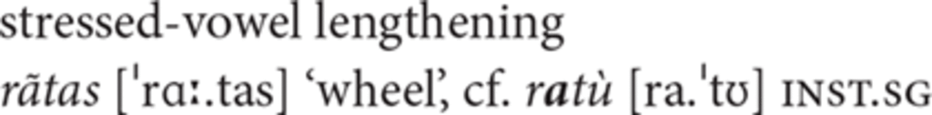

> (2)

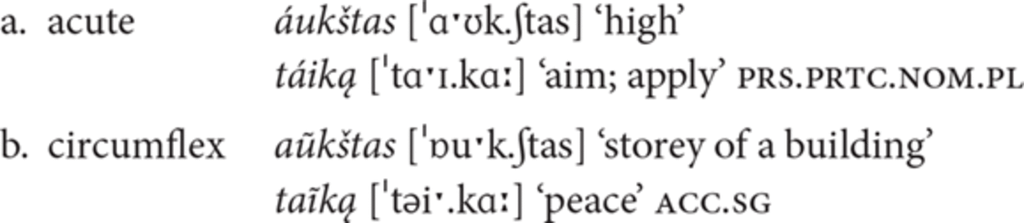

### (p. 228) 15.2.2.2 Finno-Ugric

In Estonian, the primary stress in native words always falls on the first syllable, but it may occur elsewhere in recent loans (e.g. *menüü* [meˈnyː] ‘menu’). Secondary stresses normally occur on odd-numbered syllables; their placement is determined by the derivational and syllabic structure of the word (Viitso [2003](https://www.oxfordhandbooks.com/view/10.1093/oxfordhb/9780198832232.001.0001/oxfordhb-9780198832232-bibliography-1#oxfordhb-9780198832232-bibliography-1-bibItem-4379)). The foot is maximally trisyllabic; words of more than three syllables may consist of combinations of monosyllabic, disyllabic, and trisyllabic feet (Lehiste [1997](https://www.oxfordhandbooks.com/view/10.1093/oxfordhb/9780198832232.001.0001/oxfordhb-9780198832232-bibliography-1#oxfordhb-9780198832232-bibliography-1-bibItem-2635)). A tetrasyllabic word is generally made up of two disyllabic trochees. The main phonetic correlate of stress in Estonian is vowel duration in interaction with the three-way quantity system: in long (Q2) and overlong (Q3) quantity, the stressed vowels are longer than the unstressed ones, whereas in short quantity (Q1) it is the other way round (Lippus et. al 2014).

Primary stress in Finnish always falls on the first syllable of the word (Iivonen [1998](https://www.oxfordhandbooks.com/view/10.1093/oxfordhb/9780198832232.001.0001/oxfordhb-9780198832232-bibliography-1#oxfordhb-9780198832232-bibliography-1-bibItem-2105): 315). The placement of secondary stress depends on several factors, including the segmental structure of syllables and the morphology of the word (Karlsson [1983](https://www.oxfordhandbooks.com/view/10.1093/oxfordhb/9780198832232.001.0001/oxfordhb-9780198832232-bibliography-1#oxfordhb-9780198832232-bibliography-1-bibItem-2297): 150–151; Iivonen [1998](https://www.oxfordhandbooks.com/view/10.1093/oxfordhb/9780198832232.001.0001/oxfordhb-9780198832232-bibliography-1#oxfordhb-9780198832232-bibliography-1-bibItem-2105): 315; Karvonen [2005](https://www.oxfordhandbooks.com/view/10.1093/oxfordhb/9780198832232.001.0001/oxfordhb-9780198832232-bibliography-1#oxfordhb-9780198832232-bibliography-1-bibItem-2300)). Long words are formed of disyllabic feet. In compound words, the secondary stress falls on the first syllable of the second element, even if both elements are monosyllabic (e.g. *puupää* [ˈpuːˌpæː] ‘blockhead’). The main phonetic correlate of stress in Finnish is the duration of segments when they constitute the word’s first or second mora (relative to segment durations elsewhere in the first foot) (Suomi and Ylitalo [2004](https://www.oxfordhandbooks.com/view/10.1093/oxfordhb/9780198832232.001.0001/oxfordhb-9780198832232-bibliography-1#oxfordhb-9780198832232-bibliography-1-bibItem-4074)). There is virtually no reduction of vowel quality in unstressed syllables relative to stressed syllables (Iivonen and Harnud [2005](https://www.oxfordhandbooks.com/view/10.1093/oxfordhb/9780198832232.001.0001/oxfordhb-9780198832232-bibliography-1#oxfordhb-9780198832232-bibliography-1-bibItem-2106): 65).

In Hungarian too, primary stress is fixed to the word-initial syllable but, unless the word carries a pitch accent, is not marked by salient acoustic cues such as vowel quality, duration, or intensity (Fónagy [1958](https://www.oxfordhandbooks.com/view/10.1093/oxfordhb/9780198832232.001.0001/oxfordhb-9780198832232-bibliography-1#oxfordhb-9780198832232-bibliography-1-bibItem-1381); Szalontai et al. [2016](https://www.oxfordhandbooks.com/view/10.1093/oxfordhb/9780198832232.001.0001/oxfordhb-9780198832232-bibliography-1#oxfordhb-9780198832232-bibliography-1-bibItem-4096)). The existence of secondary stress is disputed (Varga [2002](https://www.oxfordhandbooks.com/view/10.1093/oxfordhb/9780198832232.001.0001/oxfordhb-9780198832232-bibliography-1#oxfordhb-9780198832232-bibliography-1-bibItem-4343)).

### 15.2.2.3 Slavic

All modern West Slavic languages feature weight-insensitive word stress systems (van der Hulst et al. [1999](https://www.oxfordhandbooks.com/view/10.1093/oxfordhb/9780198832232.001.0001/oxfordhb-9780198832232-bibliography-1#oxfordhb-9780198832232-bibliography-1-bibItem-4289): 436). Word stress is bound in different ways to the left or to the right edge of the word. It falls on the initial syllable in Czech and Slovak but mostly on the penultimate syllable in Polish (Jassem [1962](https://www.oxfordhandbooks.com/view/10.1093/oxfordhb/9780198832232.001.0001/oxfordhb-9780198832232-bibliography-1#oxfordhb-9780198832232-bibliography-1-bibItem-2174); Steffen-Batóg [2000](https://www.oxfordhandbooks.com/view/10.1093/oxfordhb/9780198832232.001.0001/oxfordhb-9780198832232-bibliography-1#oxfordhb-9780198832232-bibliography-1-bibItem-4031)). In Czech, stress is achieved mainly by means of intensity with no systematic vowel reduction in unstressed conditions (Palková [1994](https://www.oxfordhandbooks.com/view/10.1093/oxfordhb/9780198832232.001.0001/oxfordhb-9780198832232-bibliography-1#oxfordhb-9780198832232-bibliography-1-bibItem-3285)). As an exception to the Polish penultimate syllable stress rule, stress may fall on the antepenultimate syllable in some loanwords (3a) or even on the preantepenultimate one in some verb forms (3b).

> (3)

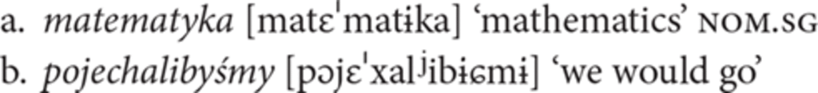

The primary stress may also move to a different syllable in order to keep its penultimate position in inflectional forms.

> (p. 229) (4)

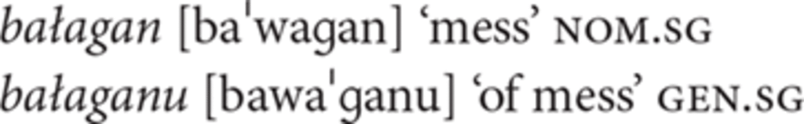

The nature of secondary stress in Polish is still under discussion (Rubach and Booij [1985](https://www.oxfordhandbooks.com/view/10.1093/oxfordhb/9780198832232.001.0001/oxfordhb-9780198832232-bibliography-1#oxfordhb-9780198832232-bibliography-1-bibItem-3711); Newlin-Łukowicz [2012](https://www.oxfordhandbooks.com/view/10.1093/oxfordhb/9780198832232.001.0001/oxfordhb-9780198832232-bibliography-1#oxfordhb-9780198832232-bibliography-1-bibItem-3138); Łukaszewicz [2018](https://www.oxfordhandbooks.com/view/10.1093/oxfordhb/9780198832232.001.0001/oxfordhb-9780198832232-bibliography-1#oxfordhb-9780198832232-bibliography-1-bibItem-2762)), with recent studies showing a lack of systematic acoustic evidence for it (Malisz and Żygis [2018](https://www.oxfordhandbooks.com/view/10.1093/oxfordhb/9780198832232.001.0001/oxfordhb-9780198832232-bibliography-1#oxfordhb-9780198832232-bibliography-1-bibItem-2814)). Similar doubts apply to Czech and Slovak.

Czech and Slovak proclitics are integrated into the prosodic word (5a), while Polish word stress preserves its position except in the case of one-syllable pronominals (5b) (Dogil [1999b](https://www.oxfordhandbooks.com/view/10.1093/oxfordhb/9780198832232.001.0001/oxfordhb-9780198832232-bibliography-1#oxfordhb-9780198832232-bibliography-1-bibItem-1116): 835).

> (5)

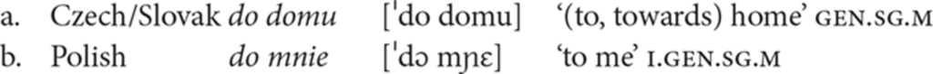

Among Western South Slavic languages, Serbian and Croatian have a lexical high tone that spreads to the syllable to its left if there is one, with some exceptions specific to the region of Zagreb (e.g. Smiljanić [2004](https://www.oxfordhandbooks.com/view/10.1093/oxfordhb/9780198832232.001.0001/oxfordhb-9780198832232-bibliography-1#oxfordhb-9780198832232-bibliography-1-bibItem-3971)). Stress in Slovenian falls on the first syllable with a strong low tone or, if there is no tone, on the last syllable (van der Hulst [2010b](https://www.oxfordhandbooks.com/view/10.1093/oxfordhb/9780198832232.001.0001/oxfordhb-9780198832232-bibliography-1#oxfordhb-9780198832232-bibliography-1-bibItem-4283): 455). Slovenian stress is independent of lexical low and high tones, which are obligatory in some dialects but optional in the standard language (Gvozdanović [1999](https://www.oxfordhandbooks.com/view/10.1093/oxfordhb/9780198832232.001.0001/oxfordhb-9780198832232-bibliography-1#oxfordhb-9780198832232-bibliography-1-bibItem-1775); Jurgec [2007](https://www.oxfordhandbooks.com/view/10.1093/oxfordhb/9780198832232.001.0001/oxfordhb-9780198832232-bibliography-1#oxfordhb-9780198832232-bibliography-1-bibItem-2245)).

East Slavic languages, Russian, Ukrainian, and Belarusian, have unbounded distinctive word stress systems where the stress may occupy any position in a word and differ across inflexional forms, for example as shown in (6).

> (6)

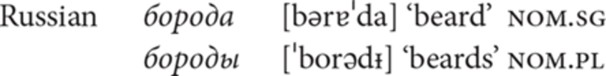

Russian is often characterized as having free-stress assignment (Danylenko and Vakulenko [1995](https://www.oxfordhandbooks.com/view/10.1093/oxfordhb/9780198832232.001.0001/oxfordhb-9780198832232-bibliography-1#oxfordhb-9780198832232-bibliography-1-bibItem-940); Hayes [1995](https://www.oxfordhandbooks.com/view/10.1093/oxfordhb/9780198832232.001.0001/oxfordhb-9780198832232-bibliography-1#oxfordhb-9780198832232-bibliography-1-bibItem-1857); Lavitskaya [2015](https://www.oxfordhandbooks.com/view/10.1093/oxfordhb/9780198832232.001.0001/oxfordhb-9780198832232-bibliography-1#oxfordhb-9780198832232-bibliography-1-bibItem-2593)). Longer word forms may feature secondary stress, but rules for its location remain a matter of dispute. Duration and intensity, the latter being less significant, are the major acoustic correlates of word stress, while pitch may be important when duration- and intensity-based cues are inconclusive (Eek [1987](https://www.oxfordhandbooks.com/view/10.1093/oxfordhb/9780198832232.001.0001/oxfordhb-9780198832232-bibliography-1#oxfordhb-9780198832232-bibliography-1-bibItem-1202): 21). Duration and intensity would also appear to be the major correlates of word stress for Ukrainian and Belarusian, but they may differ in terms of their weight (Nikolaeva [1977](https://www.oxfordhandbooks.com/view/10.1093/oxfordhb/9780198832232.001.0001/oxfordhb-9780198832232-bibliography-1#oxfordhb-9780198832232-bibliography-1-bibItem-3191): 111–113, 127–130; Łukaszewicz and Mołczanow [2018](https://www.oxfordhandbooks.com/view/10.1093/oxfordhb/9780198832232.001.0001/oxfordhb-9780198832232-bibliography-1#oxfordhb-9780198832232-bibliography-1-bibItem-2763)). In Russian, vowels are systematically (p. 230) reduced in unstressed positions (Bethin [2012](https://www.oxfordhandbooks.com/view/10.1093/oxfordhb/9780198832232.001.0001/oxfordhb-9780198832232-bibliography-1#oxfordhb-9780198832232-bibliography-1-bibItem-360)). In standard Belarusian, the contrast between non-high vowels is neutralized to [a] or a more lax [ɐ] in unstressed syllables, and vowel reduction is categorical (Czekman and Smułkowa [1988](https://www.oxfordhandbooks.com/view/10.1093/oxfordhb/9780198832232.001.0001/oxfordhb-9780198832232-bibliography-1#oxfordhb-9780198832232-bibliography-1-bibItem-914)).

### 15.2.2.4 Romance

Romanian features weight-sensitive, right-edge word stress, influenced in both verbs and nouns by derivational affixes but not by inflexional ones (Chitoran [1996](https://www.oxfordhandbooks.com/view/10.1093/oxfordhb/9780198832232.001.0001/oxfordhb-9780198832232-bibliography-1#oxfordhb-9780198832232-bibliography-1-bibItem-735); Franzen and Horne [1997](https://www.oxfordhandbooks.com/view/10.1093/oxfordhb/9780198832232.001.0001/oxfordhb-9780198832232-bibliography-1#oxfordhb-9780198832232-bibliography-1-bibItem-1415)). Vowel quality in Romanian does not change significantly across stressed and unstressed tokens. Empirical studies show greater vowel dispersion under stress and limited centralization in unstressed positions (Renwick [2014](https://www.oxfordhandbooks.com/view/10.1093/oxfordhb/9780198832232.001.0001/oxfordhb-9780198832232-bibliography-1#oxfordhb-9780198832232-bibliography-1-bibItem-3586)).

# (p. 231) 15.3 Sentence prosody

Intonational properties of the languages of the region have been studied to varying degrees employing both the more traditional contour-based methods and target-based descriptions such as the autosegmental-metrical (AM) framework (Table 15.1). Empirical studies of speech rhythm in these languages have contributed to the discussion on interval-based rhythm metrics.

Table 15.1 Available descriptions based on the autosegmental-metrical framework

[output not shown]

<sup>a</sup> The specific symbols used by Wagner ([2006](https://www.oxfordhandbooks.com/view/10.1093/oxfordhb/9780198832232.001.0001/oxfordhb-9780198832232-bibliography-1#oxfordhb-9780198832232-bibliography-1-bibItem-4401), [2008](https://www.oxfordhandbooks.com/view/10.1093/oxfordhb/9780198832232.001.0001/oxfordhb-9780198832232-bibliography-1#oxfordhb-9780198832232-bibliography-1-bibItem-4402)) have been adapted to conform with the ToBI conventions.

## 15.3.1 Baltic

Intonation in Lithuanian is characterized by a set of seven intonation patterns closely resembling the intonation constructions postulated for Russian by Bryzgunova ([1963](https://www.oxfordhandbooks.com/view/10.1093/oxfordhb/9780198832232.001.0001/oxfordhb-9780198832232-bibliography-1#oxfordhb-9780198832232-bibliography-1-bibItem-552); see also Kundrotas [2004](https://www.oxfordhandbooks.com/view/10.1093/oxfordhb/9780198832232.001.0001/oxfordhb-9780198832232-bibliography-1#oxfordhb-9780198832232-bibliography-1-bibItem-2527), [2008](https://www.oxfordhandbooks.com/view/10.1093/oxfordhb/9780198832232.001.0001/oxfordhb-9780198832232-bibliography-1#oxfordhb-9780198832232-bibliography-1-bibItem-2528), [2010](https://www.oxfordhandbooks.com/view/10.1093/oxfordhb/9780198832232.001.0001/oxfordhb-9780198832232-bibliography-1#oxfordhb-9780198832232-bibliography-1-bibItem-2529)). The patterns are distinguished by the strength of stress and pitch patterns on the stressed syllable of the intonation unit in comparison to other parts of the unit. Certain intonation contours have a neutralizing effect on the lexical pitch accents in Lithuanian (Pakerys [1982](https://www.oxfordhandbooks.com/view/10.1093/oxfordhb/9780198832232.001.0001/oxfordhb-9780198832232-bibliography-1#oxfordhb-9780198832232-bibliography-1-bibItem-3279); Girdenis [2014](https://www.oxfordhandbooks.com/view/10.1093/oxfordhb/9780198832232.001.0001/oxfordhb-9780198832232-bibliography-1#oxfordhb-9780198832232-bibliography-1-bibItem-1544)).

A similar inventory of intonation units has also been suggested for Latvian (Auziņa [2013](https://www.oxfordhandbooks.com/view/10.1093/oxfordhb/9780198832232.001.0001/oxfordhb-9780198832232-bibliography-1#oxfordhb-9780198832232-bibliography-1-bibItem-174)). The most detailed study on Latvian intonation (Tseplitis [1974](https://www.oxfordhandbooks.com/view/10.1093/oxfordhb/9780198832232.001.0001/oxfordhb-9780198832232-bibliography-1#oxfordhb-9780198832232-bibliography-1-bibItem-4219)), however, deals with ‘intonemes’ divided into several groups, conveying sentence category or speaker emotions. One sentence may be characterized by more than one intoneme, as discussed by Steffen-Batóg ([1996](https://www.oxfordhandbooks.com/view/10.1093/oxfordhb/9780198832232.001.0001/oxfordhb-9780198832232-bibliography-1#oxfordhb-9780198832232-bibliography-1-bibItem-4030)) for Polish.

## 15.3.2 Finno-Ugric

An analysis of Estonian intonation within the AM framework is provided by Asu ([2004](https://www.oxfordhandbooks.com/view/10.1093/oxfordhb/9780198832232.001.0001/oxfordhb-9780198832232-bibliography-1#oxfordhb-9780198832232-bibliography-1-bibItem-163)) (see Table 15.1). The most frequent pitch accent in both nuclear and prenuclear position is H*+L, constituting the default pattern of Estonian intonation for both declarative and interrogative utterances. Another frequent pitch accent in both read and colloquial speech is H+L* (Asu [2004](https://www.oxfordhandbooks.com/view/10.1093/oxfordhb/9780198832232.001.0001/oxfordhb-9780198832232-bibliography-1#oxfordhb-9780198832232-bibliography-1-bibItem-163); Asu and Nolan [2007](https://www.oxfordhandbooks.com/view/10.1093/oxfordhb/9780198832232.001.0001/oxfordhb-9780198832232-bibliography-1#oxfordhb-9780198832232-bibliography-1-bibItem-167)). Rising nuclei where a low tone on an accented syllable is followed by a high boundary tone (L* H%) are not uncommon, particularly in colloquial speech (Asu [2006](https://www.oxfordhandbooks.com/view/10.1093/oxfordhb/9780198832232.001.0001/oxfordhb-9780198832232-bibliography-1#oxfordhb-9780198832232-bibliography-1-bibItem-164)). Despite its flexible word order, which is largely exploited to express information structure (Lindström [2005](https://www.oxfordhandbooks.com/view/10.1093/oxfordhb/9780198832232.001.0001/oxfordhb-9780198832232-bibliography-1#oxfordhb-9780198832232-bibliography-1-bibItem-2715)), intonational prominence in Estonian signals focus, as demonstrated in research on both production (Sahkai et al. [2013](https://www.oxfordhandbooks.com/view/10.1093/oxfordhb/9780198832232.001.0001/oxfordhb-9780198832232-bibliography-1#oxfordhb-9780198832232-bibliography-1-bibItem-3736)) and perception (Salveste [2013](https://www.oxfordhandbooks.com/view/10.1093/oxfordhb/9780198832232.001.0001/oxfordhb-9780198832232-bibliography-1#oxfordhb-9780198832232-bibliography-1-bibItem-3742)). Topics/foci and new/given contrasts are, however, not signalled by accent type (Sahkai et al. [2013](https://www.oxfordhandbooks.com/view/10.1093/oxfordhb/9780198832232.001.0001/oxfordhb-9780198832232-bibliography-1#oxfordhb-9780198832232-bibliography-1-bibItem-3736)).

The basic non-emphatic utterance in Finnish is prosodically realized as a descending f0 curve consisting of rising-falling peaks on the accented syllables of all content words except finite verbs (e.g. Iivonen [1998](https://www.oxfordhandbooks.com/view/10.1093/oxfordhb/9780198832232.001.0001/oxfordhb-9780198832232-bibliography-1#oxfordhb-9780198832232-bibliography-1-bibItem-2105): 317; Suomi et al. [2008](https://www.oxfordhandbooks.com/view/10.1093/oxfordhb/9780198832232.001.0001/oxfordhb-9780198832232-bibliography-1#oxfordhb-9780198832232-bibliography-1-bibItem-4073): 114–116). This pattern is common to both statements and questions, and is used for broad and narrow focus and topic (Arnhold and Kyröläinen [2017](https://www.oxfordhandbooks.com/view/10.1093/oxfordhb/9780198832232.001.0001/oxfordhb-9780198832232-bibliography-1#oxfordhb-9780198832232-bibliography-1-bibItem-128)). Final rises are rare, while in utterance-final position creaky voice frequently occurs (Iivonen [1998](https://www.oxfordhandbooks.com/view/10.1093/oxfordhb/9780198832232.001.0001/oxfordhb-9780198832232-bibliography-1#oxfordhb-9780198832232-bibliography-1-bibItem-2105): 317; Ogden [2001](https://www.oxfordhandbooks.com/view/10.1093/oxfordhb/9780198832232.001.0001/oxfordhb-9780198832232-bibliography-1#oxfordhb-9780198832232-bibliography-1-bibItem-3240)).

(p. 232) Table 15.1 also shows the AM analysis of Finnish by Välimaa-Blum ([1993](https://www.oxfordhandbooks.com/view/10.1093/oxfordhb/9780198832232.001.0001/oxfordhb-9780198832232-bibliography-1#oxfordhb-9780198832232-bibliography-1-bibItem-4267)), which assumes two contrastive pitch accents. According to Arnhold ([2014b](https://www.oxfordhandbooks.com/view/10.1093/oxfordhb/9780198832232.001.0001/oxfordhb-9780198832232-bibliography-1#oxfordhb-9780198832232-bibliography-1-bibItem-123)), however, the rise-falls are realizations of HpLp tones associated with the prosodic phrase, and thus Finnish may be classified as a phrase language following the typology of Féry ([2015](https://www.oxfordhandbooks.com/view/10.1093/oxfordhb/9780198832232.001.0001/oxfordhb-9780198832232-bibliography-1#oxfordhb-9780198832232-bibliography-1-bibItem-1333)). Suomi et al. (2008: 122) suggest that (Northern) Finnish accents are best represented as a tritonal sequence LHL without a starred tone since the L is anchored to the onset and the H to the first mora of the (initial) stressed syllable (for a comparison of these annotations, see Arnhold [2015](https://www.oxfordhandbooks.com/view/10.1093/oxfordhb/9780198832232.001.0001/oxfordhb-9780198832232-bibliography-1#oxfordhb-9780198832232-bibliography-1-bibItem-124)).

Information structure in Finnish may be marked using f0 range, duration, intensity, pauses, and voice quality (Vainio et al. [2010](https://www.oxfordhandbooks.com/view/10.1093/oxfordhb/9780198832232.001.0001/oxfordhb-9780198832232-bibliography-1#oxfordhb-9780198832232-bibliography-1-bibItem-4257); Arnhold [2016](https://www.oxfordhandbooks.com/view/10.1093/oxfordhb/9780198832232.001.0001/oxfordhb-9780198832232-bibliography-1#oxfordhb-9780198832232-bibliography-1-bibItem-125); Arnhold and Kyröläinen [2017](https://www.oxfordhandbooks.com/view/10.1093/oxfordhb/9780198832232.001.0001/oxfordhb-9780198832232-bibliography-1#oxfordhb-9780198832232-bibliography-1-bibItem-128)) but not with categorically different f0 contours (Arnhold [2014b](https://www.oxfordhandbooks.com/view/10.1093/oxfordhb/9780198832232.001.0001/oxfordhb-9780198832232-bibliography-1#oxfordhb-9780198832232-bibliography-1-bibItem-123)). Narrow focus is signalled by a larger f0 range (Välimaa-Blum [1993](https://www.oxfordhandbooks.com/view/10.1093/oxfordhb/9780198832232.001.0001/oxfordhb-9780198832232-bibliography-1#oxfordhb-9780198832232-bibliography-1-bibItem-4267); Vainio and Järvikivi [2007](https://www.oxfordhandbooks.com/view/10.1093/oxfordhb/9780198832232.001.0001/oxfordhb-9780198832232-bibliography-1#oxfordhb-9780198832232-bibliography-1-bibItem-4258)), longer durations (Mixdorff et al. [2002](https://www.oxfordhandbooks.com/view/10.1093/oxfordhb/9780198832232.001.0001/oxfordhb-9780198832232-bibliography-1#oxfordhb-9780198832232-bibliography-1-bibItem-3002); Suomi et al. [2003](https://www.oxfordhandbooks.com/view/10.1093/oxfordhb/9780198832232.001.0001/oxfordhb-9780198832232-bibliography-1#oxfordhb-9780198832232-bibliography-1-bibItem-4072)), higher-intensity peaks, and less tense voice quality (Vainio et al. [2010](https://www.oxfordhandbooks.com/view/10.1093/oxfordhb/9780198832232.001.0001/oxfordhb-9780198832232-bibliography-1#oxfordhb-9780198832232-bibliography-1-bibItem-4257)) or increased use of creaky voice and whisper (Arnhold [2016](https://www.oxfordhandbooks.com/view/10.1093/oxfordhb/9780198832232.001.0001/oxfordhb-9780198832232-bibliography-1#oxfordhb-9780198832232-bibliography-1-bibItem-125)) as compared to broad focus, while given words have lower intensity peaks (Vainio and Järvikivi [2007](https://www.oxfordhandbooks.com/view/10.1093/oxfordhb/9780198832232.001.0001/oxfordhb-9780198832232-bibliography-1#oxfordhb-9780198832232-bibliography-1-bibItem-4258)).

As in the case of the word level, the prosody of higher units in Hungarian is left-headed. Words form accentual phrases that feature a uniform f0 contour shape, typically falling in Hungarian (Beňuš et al. [2014b](https://www.oxfordhandbooks.com/view/10.1093/oxfordhb/9780198832232.001.0001/oxfordhb-9780198832232-bibliography-1#oxfordhb-9780198832232-bibliography-1-bibItem-327)), and enhancement of the prominence of the following lexical unit (Mády et al. [2016](https://www.oxfordhandbooks.com/view/10.1093/oxfordhb/9780198832232.001.0001/oxfordhb-9780198832232-bibliography-1#oxfordhb-9780198832232-bibliography-1-bibItem-2797)). There are thorough descriptions of prosodic phrasing following the contour-based approach (Fónagy and Magdics [1967](https://www.oxfordhandbooks.com/view/10.1093/oxfordhb/9780198832232.001.0001/oxfordhb-9780198832232-bibliography-1#oxfordhb-9780198832232-bibliography-1-bibItem-1382); Varga [2002](https://www.oxfordhandbooks.com/view/10.1093/oxfordhb/9780198832232.001.0001/oxfordhb-9780198832232-bibliography-1#oxfordhb-9780198832232-bibliography-1-bibItem-4343)), and attempts at AM analyses have also been made (e.g. Kornai and Kálmán [1988](https://www.oxfordhandbooks.com/view/10.1093/oxfordhb/9780198832232.001.0001/oxfordhb-9780198832232-bibliography-1#oxfordhb-9780198832232-bibliography-1-bibItem-2454); Varga [2002](https://www.oxfordhandbooks.com/view/10.1093/oxfordhb/9780198832232.001.0001/oxfordhb-9780198832232-bibliography-1#oxfordhb-9780198832232-bibliography-1-bibItem-4343), [2008](https://www.oxfordhandbooks.com/view/10.1093/oxfordhb/9780198832232.001.0001/oxfordhb-9780198832232-bibliography-1#oxfordhb-9780198832232-bibliography-1-bibItem-4344), [2010](https://www.oxfordhandbooks.com/view/10.1093/oxfordhb/9780198832232.001.0001/oxfordhb-9780198832232-bibliography-1#oxfordhb-9780198832232-bibliography-1-bibItem-4345)).

Focus in Hungarian is located immediately before the finite verb and bears an eradicating accent (deaccenting post-verbal units) (Kálmán and Nádasdy [1994](https://www.oxfordhandbooks.com/view/10.1093/oxfordhb/9780198832232.001.0001/oxfordhb-9780198832232-bibliography-1#oxfordhb-9780198832232-bibliography-1-bibItem-2277)), typically of H+L* type (Mády [2012](https://www.oxfordhandbooks.com/view/10.1093/oxfordhb/9780198832232.001.0001/oxfordhb-9780198832232-bibliography-1#oxfordhb-9780198832232-bibliography-1-bibItem-2796); Genzel et al. [2015](https://www.oxfordhandbooks.com/view/10.1093/oxfordhb/9780198832232.001.0001/oxfordhb-9780198832232-bibliography-1#oxfordhb-9780198832232-bibliography-1-bibItem-1499)), as the following finite verb and post-verbal units are deaccented. Topics usually bear H* or L+H* accents. Morphosyntactically unmarked polar questions in Hungarian are characterized by the L* H-L% pattern, whereby the H- phrase accent has a secondary association to the penultimate syllable (Grice et al. [2000](https://www.oxfordhandbooks.com/view/10.1093/oxfordhb/9780198832232.001.0001/oxfordhb-9780198832232-bibliography-1#oxfordhb-9780198832232-bibliography-1-bibItem-1679)). In final-accented IP’s, the fall is typically truncated (Ladd [2008b](https://www.oxfordhandbooks.com/view/10.1093/oxfordhb/9780198832232.001.0001/oxfordhb-9780198832232-bibliography-1#oxfordhb-9780198832232-bibliography-1-bibItem-2546): 182). wh-questions start with a lower pitch than morphosyntactically identical wh-exclamatives (Gyuris and Mády [2014](https://www.oxfordhandbooks.com/view/10.1093/oxfordhb/9780198832232.001.0001/oxfordhb-9780198832232-bibliography-1#oxfordhb-9780198832232-bibliography-1-bibItem-1776)), while polar questions are accompanied by lower sentence-initial pitch than structurally identical declaratives (Mády and Szalontai [2014](https://www.oxfordhandbooks.com/view/10.1093/oxfordhb/9780198832232.001.0001/oxfordhb-9780198832232-bibliography-1#oxfordhb-9780198832232-bibliography-1-bibItem-2798)). They also feature different pitch accents.

## 15.3.3 Slavic

Czech linguistics has a rich tradition of analysing intonation both descriptively and in relation to information structure (Daneš [1974](https://www.oxfordhandbooks.com/view/10.1093/oxfordhb/9780198832232.001.0001/oxfordhb-9780198832232-bibliography-1#oxfordhb-9780198832232-bibliography-1-bibItem-934); Firbas [1992](https://www.oxfordhandbooks.com/view/10.1093/oxfordhb/9780198832232.001.0001/oxfordhb-9780198832232-bibliography-1#oxfordhb-9780198832232-bibliography-1-bibItem-1346); Hajičová et al. [1998](https://www.oxfordhandbooks.com/view/10.1093/oxfordhb/9780198832232.001.0001/oxfordhb-9780198832232-bibliography-1#oxfordhb-9780198832232-bibliography-1-bibItem-1784); Hajičová [2012](https://www.oxfordhandbooks.com/view/10.1093/oxfordhb/9780198832232.001.0001/oxfordhb-9780198832232-bibliography-1#oxfordhb-9780198832232-bibliography-1-bibItem-1783)). Daneš ([1957](https://www.oxfordhandbooks.com/view/10.1093/oxfordhb/9780198832232.001.0001/oxfordhb-9780198832232-bibliography-1#oxfordhb-9780198832232-bibliography-1-bibItem-933)), Romportl ([1973](https://www.oxfordhandbooks.com/view/10.1093/oxfordhb/9780198832232.001.0001/oxfordhb-9780198832232-bibliography-1#oxfordhb-9780198832232-bibliography-1-bibItem-3668)), and Palková ([1994](https://www.oxfordhandbooks.com/view/10.1093/oxfordhb/9780198832232.001.0001/oxfordhb-9780198832232-bibliography-1#oxfordhb-9780198832232-bibliography-1-bibItem-3285)) provide the foundational studies that differentiate three basic types of melodic pattern (commonly referred to as ‘melodeme’ or ‘cadence’) for neutral speech: (i) complete/concluding falling (e.g. declaratives, wh-questions, imperatives), (ii) complete/concluding rising (e.g. polar questions), and (iii) incomplete/continuative for syntactically incomplete units. These basic types may be further modified, for example in the placement of sentence stress, interval size of adjacent syllables, or other ways, to convey expressivity and modality of the phrases.

(p. 233) In what is probably the most complete analysis of Czech intonation, Duběda ([2014](https://www.oxfordhandbooks.com/view/10.1093/oxfordhb/9780198832232.001.0001/oxfordhb-9780198832232-bibliography-1#oxfordhb-9780198832232-bibliography-1-bibItem-1164)) combines the AM framework with contour-based descriptions from Duběda and Raab ([2008](https://www.oxfordhandbooks.com/view/10.1093/oxfordhb/9780198832232.001.0001/oxfordhb-9780198832232-bibliography-1#oxfordhb-9780198832232-bibliography-1-bibItem-1165)) (see Table 15.1).

Slovak, like Czech, offers the potential for unique research in intonational phonology due to the relative flexibility of its word order; the relationship between pitch accents and boundary marking, which falls in between that of Germanic languages (with a rather independent relationship) and that of Hungarian or French (with a tightly linked relationship between the two); and the numerous links to cross-linguistic research on the relation of intonation to information structure in Czech and Hungarian. Earlier descriptions of Slovak intonation follow the Czech tradition, listing typical intonational contours for pragmatic functions, and primarily use the degree of finality or completeness for basic taxonomy (e.g. Kráľ [1988](https://www.oxfordhandbooks.com/view/10.1093/oxfordhb/9780198832232.001.0001/oxfordhb-9780198832232-bibliography-1#oxfordhb-9780198832232-bibliography-1-bibItem-2467)).

For a description of Slovak intonation within an AM framework, see Table 15.1. Using a data-driven, bottom-up, parametric method of intonation stylization, Slovak contours of an intermediate domain identified as the accentual phrase (α) have been shown to have a primarily convex (rising-falling) shape, suggesting that trailing tones might align with unstressed syllables (Reichel et al. [2015](https://www.oxfordhandbooks.com/view/10.1093/oxfordhb/9780198832232.001.0001/oxfordhb-9780198832232-bibliography-1#oxfordhb-9780198832232-bibliography-1-bibItem-3564)).

One of the most comprehensive studies of Polish intonation (Steffen-Batóg [1996](https://www.oxfordhandbooks.com/view/10.1093/oxfordhb/9780198832232.001.0001/oxfordhb-9780198832232-bibliography-1#oxfordhb-9780198832232-bibliography-1-bibItem-4030)) operates within its idiosyncratic framework, offering a hierarchy of prosodic domains involving intonational phrases, intonemes (melodic patterns), tonal units, and intonation units. Studies inspired by the British School propose inventories of seven or eight nuclear melodies (Demenko [1999](https://www.oxfordhandbooks.com/view/10.1093/oxfordhb/9780198832232.001.0001/oxfordhb-9780198832232-bibliography-1#oxfordhb-9780198832232-bibliography-1-bibItem-1015); Demenko and Jassem [1999](https://www.oxfordhandbooks.com/view/10.1093/oxfordhb/9780198832232.001.0001/oxfordhb-9780198832232-bibliography-1#oxfordhb-9780198832232-bibliography-1-bibItem-1016); Francuzik et al. [2005](https://www.oxfordhandbooks.com/view/10.1093/oxfordhb/9780198832232.001.0001/oxfordhb-9780198832232-bibliography-1#oxfordhb-9780198832232-bibliography-1-bibItem-1410); Karpiński [2006](https://www.oxfordhandbooks.com/view/10.1093/oxfordhb/9780198832232.001.0001/oxfordhb-9780198832232-bibliography-1#oxfordhb-9780198832232-bibliography-1-bibItem-2299); see Table 15.1 for an AM-based representation). As word order in Polish does not determine sentence category, intonation strongly influences its identification and may override lexical cues (e.g. question words). Overall intensity, duration, and pitch are the main acoustic correlates of phrase accent but not necessarily of word stress (Malisz and Wagner [2012](https://www.oxfordhandbooks.com/view/10.1093/oxfordhb/9780198832232.001.0001/oxfordhb-9780198832232-bibliography-1#oxfordhb-9780198832232-bibliography-1-bibItem-2813); Newlin-Łukowicz [2012](https://www.oxfordhandbooks.com/view/10.1093/oxfordhb/9780198832232.001.0001/oxfordhb-9780198832232-bibliography-1#oxfordhb-9780198832232-bibliography-1-bibItem-3138)).

In earlier work (Bryzgunova [1963](https://www.oxfordhandbooks.com/view/10.1093/oxfordhb/9780198832232.001.0001/oxfordhb-9780198832232-bibliography-1#oxfordhb-9780198832232-bibliography-1-bibItem-552)/1967), Russian intonation was described in terms of five phonological intonational constructions (IKs) that have several non-phonemic variants. IK-1 is typical of statements; IK-2 of wh-questions; IK-3 of questions without a question word. IK-4 occurs in incomplete questions (‘And you?’), while IK-5 is used for exclamations. Intonation may determine utterance category (e.g. question vs. statement). In utterances built of multiple syntagmas, intonation is more probably paralinguistic and reflects mostly feelings and attitudes (Bryzgunova [1963](https://www.oxfordhandbooks.com/view/10.1093/oxfordhb/9780198832232.001.0001/oxfordhb-9780198832232-bibliography-1#oxfordhb-9780198832232-bibliography-1-bibItem-552)/1967). Each IK has a centre, which is the accented syllable of one of its words. The IK centre may be optionally preceded by a pre-tonic part and followed by a post-tonic part. Other descriptions of Russian intonation include Nikolaeva ([1982](https://www.oxfordhandbooks.com/view/10.1093/oxfordhb/9780198832232.001.0001/oxfordhb-9780198832232-bibliography-1#oxfordhb-9780198832232-bibliography-1-bibItem-3192)) and Svetozarova ([1982](https://www.oxfordhandbooks.com/view/10.1093/oxfordhb/9780198832232.001.0001/oxfordhb-9780198832232-bibliography-1#oxfordhb-9780198832232-bibliography-1-bibItem-4084), [1998](https://www.oxfordhandbooks.com/view/10.1093/oxfordhb/9780198832232.001.0001/oxfordhb-9780198832232-bibliography-1#oxfordhb-9780198832232-bibliography-1-bibItem-4085)), based on the pragmatic functions of intonation, and the Institute for Perception Research approach (Odé [1989](https://www.oxfordhandbooks.com/view/10.1093/oxfordhb/9780198832232.001.0001/oxfordhb-9780198832232-bibliography-1#oxfordhb-9780198832232-bibliography-1-bibItem-3229)) and some strictly acoustic-phonetic studies (Kodzasov [1996](https://www.oxfordhandbooks.com/view/10.1093/oxfordhb/9780198832232.001.0001/oxfordhb-9780198832232-bibliography-1#oxfordhb-9780198832232-bibliography-1-bibItem-2426)). Odé ([2008](https://www.oxfordhandbooks.com/view/10.1093/oxfordhb/9780198832232.001.0001/oxfordhb-9780198832232-bibliography-1#oxfordhb-9780198832232-bibliography-1-bibItem-3233)) established an AM-based transcription system for Russian intonation (see Table 15.1). A perception experiment by Odé ([2005](https://www.oxfordhandbooks.com/view/10.1093/oxfordhb/9780198832232.001.0001/oxfordhb-9780198832232-bibliography-1#oxfordhb-9780198832232-bibliography-1-bibItem-3232)) suggests that the truncation of the final fall in the interrogative tune LH*L does not cause a neutralization of the contrast with declarative H*L, meaning that the truncation is phonetic rather than due to a phonological tone deletion. In Ukrainian, pitch accents are associated with prominent syllables, depending on information structure and the position in an utterance. A rising-falling or falling intonation is (p. 234) typical of the main stressed syllable, which is normally longer than non-stressed ones. Unstressed syllables can become longer in phrase-final positions (Pompino-Marschall et al. [2016](https://www.oxfordhandbooks.com/view/10.1093/oxfordhb/9780198832232.001.0001/oxfordhb-9780198832232-bibliography-1#oxfordhb-9780198832232-bibliography-1-bibItem-3447)). Statements, wh-questions, and exclamations are most often based on falling contours, while polar questions and continuation are formed with rising contours (Bagmut et al. [1985](https://www.oxfordhandbooks.com/view/10.1093/oxfordhb/9780198832232.001.0001/oxfordhb-9780198832232-bibliography-1#oxfordhb-9780198832232-bibliography-1-bibItem-197)). Narrow focus in Ukranian is signalled by H*L while broad foci are realized with a prenuclear LH* followed by a nuclear HL* accent (Féry et al. [1997](https://www.oxfordhandbooks.com/view/10.1093/oxfordhb/9780198832232.001.0001/oxfordhb-9780198832232-bibliography-1#oxfordhb-9780198832232-bibliography-1-bibItem-1339)). Work on Belarusian intonation is even more limited. Nikolaeva ([1977](https://www.oxfordhandbooks.com/view/10.1093/oxfordhb/9780198832232.001.0001/oxfordhb-9780198832232-bibliography-1#oxfordhb-9780198832232-bibliography-1-bibItem-3191): 101–103) proposes five variants of phrase melody for phrases closing with an accented syllable and four for those where post-accented syllables are present. She also analyses the melody of incomplete syntagmas.

Traditional analyses of BCMS intonation (Lehiste and Ivić [1963](https://www.oxfordhandbooks.com/view/10.1093/oxfordhb/9780198832232.001.0001/oxfordhb-9780198832232-bibliography-1#oxfordhb-9780198832232-bibliography-1-bibItem-2636), [1986](https://www.oxfordhandbooks.com/view/10.1093/oxfordhb/9780198832232.001.0001/oxfordhb-9780198832232-bibliography-1#oxfordhb-9780198832232-bibliography-1-bibItem-2637); Browne and McCawley [1965](https://www.oxfordhandbooks.com/view/10.1093/oxfordhb/9780198832232.001.0001/oxfordhb-9780198832232-bibliography-1#oxfordhb-9780198832232-bibliography-1-bibItem-524); Nikolić [1970](https://www.oxfordhandbooks.com/view/10.1093/oxfordhb/9780198832232.001.0001/oxfordhb-9780198832232-bibliography-1#oxfordhb-9780198832232-bibliography-1-bibItem-3193); Gvozdanović [1980](https://www.oxfordhandbooks.com/view/10.1093/oxfordhb/9780198832232.001.0001/oxfordhb-9780198832232-bibliography-1#oxfordhb-9780198832232-bibliography-1-bibItem-1774); Kostić [1983](https://www.oxfordhandbooks.com/view/10.1093/oxfordhb/9780198832232.001.0001/oxfordhb-9780198832232-bibliography-1#oxfordhb-9780198832232-bibliography-1-bibItem-2458); Inkelas and Zec [1988](https://www.oxfordhandbooks.com/view/10.1093/oxfordhb/9780198832232.001.0001/oxfordhb-9780198832232-bibliography-1#oxfordhb-9780198832232-bibliography-1-bibItem-2124); Stevanović [1989](https://www.oxfordhandbooks.com/view/10.1093/oxfordhb/9780198832232.001.0001/oxfordhb-9780198832232-bibliography-1#oxfordhb-9780198832232-bibliography-1-bibItem-4041)) distinguish four lexical pitch accents: short falling, long falling, short rising, and long rising. Within the AM framework, the BCMS accent distinction is analysed as based on the location of a lexically specified H tone, associated with the tonic syllable in the case of falling accents and with the post-tonic syllable (spreading one syllable to the left) in the case of rising accents (Inkelas and Zec [1988](https://www.oxfordhandbooks.com/view/10.1093/oxfordhb/9780198832232.001.0001/oxfordhb-9780198832232-bibliography-1#oxfordhb-9780198832232-bibliography-1-bibItem-2124); cf. Zec [1993](https://www.oxfordhandbooks.com/view/10.1093/oxfordhb/9780198832232.001.0001/oxfordhb-9780198832232-bibliography-1#oxfordhb-9780198832232-bibliography-1-bibItem-4651), [1994](https://www.oxfordhandbooks.com/view/10.1093/oxfordhb/9780198832232.001.0001/oxfordhb-9780198832232-bibliography-1#oxfordhb-9780198832232-bibliography-1-bibItem-4652)). The L tones are assigned to the tone-bearing units post-lexically by default. Godjevac ([2000](https://www.oxfordhandbooks.com/view/10.1093/oxfordhb/9780198832232.001.0001/oxfordhb-9780198832232-bibliography-1#oxfordhb-9780198832232-bibliography-1-bibItem-1554), [2005](https://www.oxfordhandbooks.com/view/10.1093/oxfordhb/9780198832232.001.0001/oxfordhb-9780198832232-bibliography-1#oxfordhb-9780198832232-bibliography-1-bibItem-1555)) provides an alternative analysis that argues for a sparse specification of tones (see Table 15.1). The %L boundary tone occurs in broad-focus utterances and the %H signals narrow contrastive or corrective focus. HL% is used for the vocative chant. The LH- phrase accent is a property of the focused word in polar questions. The phonetic implementation of the lexical pitch accents is determined by an interaction of lexical, pragmatic, and prosodic factors (Inkelas and Zec [1988](https://www.oxfordhandbooks.com/view/10.1093/oxfordhb/9780198832232.001.0001/oxfordhb-9780198832232-bibliography-1#oxfordhb-9780198832232-bibliography-1-bibItem-2124); Smiljanić [2004](https://www.oxfordhandbooks.com/view/10.1093/oxfordhb/9780198832232.001.0001/oxfordhb-9780198832232-bibliography-1#oxfordhb-9780198832232-bibliography-1-bibItem-3971)).

The traditional model of Slovenian intonation (Jože [1967](https://www.oxfordhandbooks.com/view/10.1093/oxfordhb/9780198832232.001.0001/oxfordhb-9780198832232-bibliography-1#oxfordhb-9780198832232-bibliography-1-bibItem-2213)) proposes different types of contour for statements, commands, and questions, with an inventory of three nuclear tones: fall (cadent), rise (anti-cadent), and level (semi-cadent). On the basis of an extensive corpus of dialogues and O’Connor and Arnold’s (1973) model of British English intonation, Šuštaršič ([1995](https://www.oxfordhandbooks.com/view/10.1093/oxfordhb/9780198832232.001.0001/oxfordhb-9780198832232-bibliography-1#oxfordhb-9780198832232-bibliography-1-bibItem-4078)) established that Slovenian intonation is by no means restricted to falling, rising, and level nuclear tones. Television news and sport broadcasters were found to use fall-rise pitch movement to introduce new information (the fall) and to point to semantic and syntactic non-finality (the rise). There are seven possible combinations of key and termination establishing cohesive and coherent links between a series of tone units (Komar [1999](https://www.oxfordhandbooks.com/view/10.1093/oxfordhb/9780198832232.001.0001/oxfordhb-9780198832232-bibliography-1#oxfordhb-9780198832232-bibliography-1-bibItem-2440), [2006](https://www.oxfordhandbooks.com/view/10.1093/oxfordhb/9780198832232.001.0001/oxfordhb-9780198832232-bibliography-1#oxfordhb-9780198832232-bibliography-1-bibItem-2441), [2008](https://www.oxfordhandbooks.com/view/10.1093/oxfordhb/9780198832232.001.0001/oxfordhb-9780198832232-bibliography-1#oxfordhb-9780198832232-bibliography-1-bibItem-2442), based on Brazil’s 1997 framework).

In Bulgarian, intonation is studied according to different sentence types: question, statement, exclamation, and command (Nikolaeva [1977](https://www.oxfordhandbooks.com/view/10.1093/oxfordhb/9780198832232.001.0001/oxfordhb-9780198832232-bibliography-1#oxfordhb-9780198832232-bibliography-1-bibItem-3191); Tilkov [1981](https://www.oxfordhandbooks.com/view/10.1093/oxfordhb/9780198832232.001.0001/oxfordhb-9780198832232-bibliography-1#oxfordhb-9780198832232-bibliography-1-bibItem-4167); Miševa [1991](https://www.oxfordhandbooks.com/view/10.1093/oxfordhb/9780198832232.001.0001/oxfordhb-9780198832232-bibliography-1#oxfordhb-9780198832232-bibliography-1-bibItem-2990)). Following the American structuralist approach, Penčev ([1980](https://www.oxfordhandbooks.com/view/10.1093/oxfordhb/9780198832232.001.0001/oxfordhb-9780198832232-bibliography-1#oxfordhb-9780198832232-bibliography-1-bibItem-3344)) postulates 10 basic intonation contours, six neutral (depending on the focus position), and four emphatic (regardless of the focus position). Earlier studies on the relationship between intonation and information structure (Miševa [1991](https://www.oxfordhandbooks.com/view/10.1093/oxfordhb/9780198832232.001.0001/oxfordhb-9780198832232-bibliography-1#oxfordhb-9780198832232-bibliography-1-bibItem-2990); Miševa and Nikov [1998](https://www.oxfordhandbooks.com/view/10.1093/oxfordhb/9780198832232.001.0001/oxfordhb-9780198832232-bibliography-1#oxfordhb-9780198832232-bibliography-1-bibItem-2991)) demonstrate that themes are deaccented, and rhemes of narrow and broad focus are realized with the same intonational pattern, but the contrast between the prominent and the surrounding syllables is greater in narrow focus than in broad focus.

Andreeva ([2007](https://www.oxfordhandbooks.com/view/10.1093/oxfordhb/9780198832232.001.0001/oxfordhb-9780198832232-bibliography-1#oxfordhb-9780198832232-bibliography-1-bibItem-85)) develops an AM-based analysis of Bulgarian intonation (see Table 15.1). The default nuclear pattern for declaratives is H+!H* L-%, and for polar questions L*+H (p. 235) L-%.<sup>1</sup> L*+H is predominant in prenuclear position. Given information is not necessarily deaccented. Givenness lowers the pitch accent in prenuclear positions and usually cancels it out in a postnuclear position (Avgustinova and Andreeva [1999](https://www.oxfordhandbooks.com/view/10.1093/oxfordhb/9780198832232.001.0001/oxfordhb-9780198832232-bibliography-1#oxfordhb-9780198832232-bibliography-1-bibItem-184); Andreeva et al. [2001](https://www.oxfordhandbooks.com/view/10.1093/oxfordhb/9780198832232.001.0001/oxfordhb-9780198832232-bibliography-1#oxfordhb-9780198832232-bibliography-1-bibItem-86)). The same focus type is not always expressed with the same pitch accent (Andreeva and Oliver [2005](https://www.oxfordhandbooks.com/view/10.1093/oxfordhb/9780198832232.001.0001/oxfordhb-9780198832232-bibliography-1#oxfordhb-9780198832232-bibliography-1-bibItem-89); Dimitrova and Jun [2015](https://www.oxfordhandbooks.com/view/10.1093/oxfordhb/9780198832232.001.0001/oxfordhb-9780198832232-bibliography-1#oxfordhb-9780198832232-bibliography-1-bibItem-1078); Andreeva et al. [2016](https://www.oxfordhandbooks.com/view/10.1093/oxfordhb/9780198832232.001.0001/oxfordhb-9780198832232-bibliography-1#oxfordhb-9780198832232-bibliography-1-bibItem-88)). Andreeva et al. (2016) showed that speakers employ both local and global prosodic cues in terms of duration, peak alignment, mean f0, f0 change, intensity, and spectral balance to obtain the contrast between different focus conditions.

Apart from a few instrumental studies on intonation in Macedonian (Nikolaeva [1977](https://www.oxfordhandbooks.com/view/10.1093/oxfordhb/9780198832232.001.0001/oxfordhb-9780198832232-bibliography-1#oxfordhb-9780198832232-bibliography-1-bibItem-3191); Sawicka [1991](https://www.oxfordhandbooks.com/view/10.1093/oxfordhb/9780198832232.001.0001/oxfordhb-9780198832232-bibliography-1#oxfordhb-9780198832232-bibliography-1-bibItem-3773); Sawicka and Spasov [1997](https://www.oxfordhandbooks.com/view/10.1093/oxfordhb/9780198832232.001.0001/oxfordhb-9780198832232-bibliography-1#oxfordhb-9780198832232-bibliography-1-bibItem-3774)), there are no theoretical contributions using contemporary phonological frameworks.

## 15.3.4 Romance

For an AM-based system for Romanian see Table 15.1. The most frequently occurring pitch accent is H*, which is aligned with the end of the stressed syllable. L+<H* is only used in prenuclear position. The ‘neutral’ nuclear configuration for statements is H+L* L%. In comparison with broad focus, narrow focus is signalled by expanded pitch range on the word in focus and by compressing the durations of the adjacent words (Manolescu et al. [2009](https://www.oxfordhandbooks.com/view/10.1093/oxfordhb/9780198832232.001.0001/oxfordhb-9780198832232-bibliography-1#oxfordhb-9780198832232-bibliography-1-bibItem-2823)). Nuclear stress is on the verb in polar questions and on the wh-word (followed by a post-focal accent in long sentences) in wh-questions, a pattern typical also of Hungarian, Greek, and the Slavic languages (Ladd [1996](https://www.oxfordhandbooks.com/view/10.1093/oxfordhb/9780198832232.001.0001/oxfordhb-9780198832232-bibliography-1#oxfordhb-9780198832232-bibliography-1-bibItem-2544); Apopeiu et al. [2006](https://www.oxfordhandbooks.com/view/10.1093/oxfordhb/9780198832232.001.0001/oxfordhb-9780198832232-bibliography-1#oxfordhb-9780198832232-bibliography-1-bibItem-97)). Regarding the prosodic marking of information status, Romanian (like many other Romance languages; see chapters [16](https://www.oxfordhandbooks.com/view/10.1093/oxfordhb/9780198832232.001.0001/oxfordhb-9780198832232-e-15#) and [17](https://www.oxfordhandbooks.com/view/10.1093/oxfordhb/9780198832232.001.0001/oxfordhb-9780198832232-e-16#)) resists deaccentuation (Ladd [1996](https://www.oxfordhandbooks.com/view/10.1093/oxfordhb/9780198832232.001.0001/oxfordhb-9780198832232-bibliography-1#oxfordhb-9780198832232-bibliography-1-bibItem-2544); Swerts [2007](https://www.oxfordhandbooks.com/view/10.1093/oxfordhb/9780198832232.001.0001/oxfordhb-9780198832232-bibliography-1#oxfordhb-9780198832232-bibliography-1-bibItem-4088)).

*On rhythm*. Finally, empirically established rhythmic properties have been reported for Lithuanian and Latvian (Stockmal et al. [2005](https://www.oxfordhandbooks.com/view/10.1093/oxfordhb/9780198832232.001.0001/oxfordhb-9780198832232-bibliography-1#oxfordhb-9780198832232-bibliography-1-bibItem-4044); Kazlauskienė [2015](https://www.oxfordhandbooks.com/view/10.1093/oxfordhb/9780198832232.001.0001/oxfordhb-9780198832232-bibliography-1#oxfordhb-9780198832232-bibliography-1-bibItem-2319)), Estonian (Asu and Nolan [2006](https://www.oxfordhandbooks.com/view/10.1093/oxfordhb/9780198832232.001.0001/oxfordhb-9780198832232-bibliography-1#oxfordhb-9780198832232-bibliography-1-bibItem-166); Nolan and Asu [2009](https://www.oxfordhandbooks.com/view/10.1093/oxfordhb/9780198832232.001.0001/oxfordhb-9780198832232-bibliography-1#oxfordhb-9780198832232-bibliography-1-bibItem-3200)), Finnish (Leino [1986](https://www.oxfordhandbooks.com/view/10.1093/oxfordhb/9780198832232.001.0001/oxfordhb-9780198832232-bibliography-1#oxfordhb-9780198832232-bibliography-1-bibItem-2642): 154; Wiik [1989](https://www.oxfordhandbooks.com/view/10.1093/oxfordhb/9780198832232.001.0001/oxfordhb-9780198832232-bibliography-1#oxfordhb-9780198832232-bibliography-1-bibItem-4538); O’Dell et al. [2008](https://www.oxfordhandbooks.com/view/10.1093/oxfordhb/9780198832232.001.0001/oxfordhb-9780198832232-bibliography-1#oxfordhb-9780198832232-bibliography-1-bibItem-3235)), Hungarian (White et al. [2012](https://www.oxfordhandbooks.com/view/10.1093/oxfordhb/9780198832232.001.0001/oxfordhb-9780198832232-bibliography-1#oxfordhb-9780198832232-bibliography-1-bibItem-4523)), Bulgarian (Dimitrova [1997](https://www.oxfordhandbooks.com/view/10.1093/oxfordhb/9780198832232.001.0001/oxfordhb-9780198832232-bibliography-1#oxfordhb-9780198832232-bibliography-1-bibItem-1077); Barry et al. [2009](https://www.oxfordhandbooks.com/view/10.1093/oxfordhb/9780198832232.001.0001/oxfordhb-9780198832232-bibliography-1#oxfordhb-9780198832232-bibliography-1-bibItem-247)), Czech and Slovak (Dankovičová and Dellwo [2007](https://www.oxfordhandbooks.com/view/10.1093/oxfordhb/9780198832232.001.0001/oxfordhb-9780198832232-bibliography-1#oxfordhb-9780198832232-bibliography-1-bibItem-937); Beňuš and Šimko [2012](https://www.oxfordhandbooks.com/view/10.1093/oxfordhb/9780198832232.001.0001/oxfordhb-9780198832232-bibliography-1#oxfordhb-9780198832232-bibliography-1-bibItem-328)), Polish (Malisz [2013](https://www.oxfordhandbooks.com/view/10.1093/oxfordhb/9780198832232.001.0001/oxfordhb-9780198832232-bibliography-1#oxfordhb-9780198832232-bibliography-1-bibItem-2811); Klessa [2016](https://www.oxfordhandbooks.com/view/10.1093/oxfordhb/9780198832232.001.0001/oxfordhb-9780198832232-bibliography-1#oxfordhb-9780198832232-bibliography-1-bibItem-2412); Wagner et al. [2016](https://www.oxfordhandbooks.com/view/10.1093/oxfordhb/9780198832232.001.0001/oxfordhb-9780198832232-bibliography-1#oxfordhb-9780198832232-bibliography-1-bibItem-4404); Wagner [2017](https://www.oxfordhandbooks.com/view/10.1093/oxfordhb/9780198832232.001.0001/oxfordhb-9780198832232-bibliography-1#oxfordhb-9780198832232-bibliography-1-bibItem-4403)), Russian (Zlatoustova [1975](https://www.oxfordhandbooks.com/view/10.1093/oxfordhb/9780198832232.001.0001/oxfordhb-9780198832232-bibliography-1#oxfordhb-9780198832232-bibliography-1-bibItem-4687); Ordin and Setter [2008a](https://www.oxfordhandbooks.com/view/10.1093/oxfordhb/9780198832232.001.0001/oxfordhb-9780198832232-bibliography-1#oxfordhb-9780198832232-bibliography-1-bibItem-3251), [2008b](https://www.oxfordhandbooks.com/view/10.1093/oxfordhb/9780198832232.001.0001/oxfordhb-9780198832232-bibliography-1#oxfordhb-9780198832232-bibliography-1-bibItem-3252)), Ukrainian (Ishchenko [2015](https://www.oxfordhandbooks.com/view/10.1093/oxfordhb/9780198832232.001.0001/oxfordhb-9780198832232-bibliography-1#oxfordhb-9780198832232-bibliography-1-bibItem-2132)), Serbian (Rakić [2010](https://www.oxfordhandbooks.com/view/10.1093/oxfordhb/9780198832232.001.0001/oxfordhb-9780198832232-bibliography-1#oxfordhb-9780198832232-bibliography-1-bibItem-3525); Bjelica [2012](https://www.oxfordhandbooks.com/view/10.1093/oxfordhb/9780198832232.001.0001/oxfordhb-9780198832232-bibliography-1#oxfordhb-9780198832232-bibliography-1-bibItem-386); Marković and Milićev [2017](https://www.oxfordhandbooks.com/view/10.1093/oxfordhb/9780198832232.001.0001/oxfordhb-9780198832232-bibliography-1#oxfordhb-9780198832232-bibliography-1-bibItem-2829)), Croatian (Josipović [1994](https://www.oxfordhandbooks.com/view/10.1093/oxfordhb/9780198832232.001.0001/oxfordhb-9780198832232-bibliography-1#oxfordhb-9780198832232-bibliography-1-bibItem-2209)), and Romanian (Chitoran [1996](https://www.oxfordhandbooks.com/view/10.1093/oxfordhb/9780198832232.001.0001/oxfordhb-9780198832232-bibliography-1#oxfordhb-9780198832232-bibliography-1-bibItem-735)).

# 15.4 Conclusion

The prosodic systems of Central and Eastern Europe offer an exciting, promising, and multi-faceted area for extending our understanding of the role of prosody in the linguistic system. However, it was only possible in this chapter to provide a cursory picture of the prosody of the area’s main languages. Multiple issues and problems within prosodic systems and their interfaces with the rest of the linguistic system could not be discussed. Among them, there are the relationships between quantity, intensity, and pitch, which are interrelated in complex ways (e.g. quantity and f0 in Finnish and Estonian or lexical tones in Baltic languages, and cross-linguistic differences in their impact in cueing word stress patterns). More light also needs to be shed on coding and decoding of the prosodic prominence and its acoustic-phonetic correlates, as recent research still reveals facts incoherent with traditional views (e.g. the secondary stress in Polish). Another issue is the interface of prosody with syntax and information structure, with important steps already made for Czech, Hungarian, and Estonian. The richness and complexity of the relationship between prosody and surface word order, which is free in some of the area’s languages, offers a unique testbed for hypotheses and models regarding the cognitive aspects of meaning. A different type of issue for future research concerns the prosodic aspects of language variation within the Slavic dialect continuum as well as with contiguous non-Slavic languages.

## Notes:

(<sup>1</sup>) According to Grice et al. ([2005a](https://www.oxfordhandbooks.com/view/10.1093/oxfordhb/9780198832232.001.0001/oxfordhb-9780198832232-bibliography-1#oxfordhb-9780198832232-bibliography-1-bibItem-1675)), in cases where phrase accents and boundary tones represent the same pitch level, only one tone is transcribed: L-% instead of L-L%.

Maciej Karpiński

Maciej Karpiński is a Professor in the Faculty of Modern Languages and Literatures of Adam Mickiewicz University, Poznań. He holds a PhD in general linguistics and a postdoctoral degree in applied linguistics. Focusing on pragma-phonetic and paralinguistic aspects of communication, he has recently investigated the contribution of prosody and gestures to the process of communicative accommodation and the influence of social factors, emotional states, and physical conditions on speech prosody. He has developed a number of linguistic corpora and contributed to projects on language documentation.

Bistra Andreeva

Bistra Andreeva is Professor of Phonetics and Phonology in the Department of Language Science and Technology, Saarland University. Her major research interests include the phonetics and phonology of intonation and rhythm, cross-language and individual differences in the production and perception of syllabic prominence in various languages, the relation between intonation and information structure, and the interaction between information density and prosodic structure.

Eva Liina Asu

Eva Liina Asu is an Associate Professor of Swedish and Phonetics at the University of Tartu. She obtained her PhD in Linguistics at the University of Cambridge in 2004. Her research focuses on various prosodic aspects of Estonian including the phonetics and phonology of intonation, rhythm, stress, and quantity. She is also interested in prosodic and segmental features of Estonian Swedish in comparison with other varieties of Swedish.

Anna Daugavet

Anna Daugavet is an Assistant Professor at the Department of General Linguistics of Saint Petersburg State University, where she teaches courses on Lithuanian and Latvian dialectology and areal features of the Baltic languages. She completed her PhD in linguistics at Saint Petersburg University in 2009. Her research interests include syllable weight, tone, and stress.

Štefan Beňuš

Štefan Beňuš is an Associate Professor in the Department of English and American Studies at Constantine the Philosopher University and a Senior Researcher in Speech Sciences at the Institute of Informatics of the Slovak Academy of Sciences in Bratislava. He holds a PhD in linguistics from New York University and postdoctoral qualifications from Columbia University and LMU Munich. His research centres on the relationship between (i) speech prosody and the pragmatic/discourse aspect of the message and (ii) phonetics and phonology, with a special interest in the articulatory characteristics of speech. He previously served as an associate editor of Laboratory Phonology and regularly presents at major conferences, such as Speech Prosody and Interspeech.

Katalin Mády

Katalin Mády is a Senior Researcher at the Hungarian Research Institute for Linguistics, Budapest. After finishing her PhD on clinical phonetics at the Institute of Phonetics and Speech Processing (IPS), LMU Munich in 2004, she became Assistant Professor in German linguistics at the Pázmány Péter Catholic University. She returned to IPS LMU as a postdoctoral researcher in 2006 to do research in sociophonetics, laboratory phonology, and prosody. Her current work mainly focuses on prosodic typology, with a special interest in Uralic and other understudied languages in Central and Eastern Europe.